# am-lab-9

# Is this an overestimate or an underestimate, and by how much?

# In other words, what is the residual for this prediction?

# Model diagnostics

#To assess whether the linear model is reliable, we need to check for # (1) linearity, (2) nearly normal residuals, and (3) constant variability.

#Linearity: You already checked if the relationship between runs and at-bats is linear #using a scatterplot. We should also verify this condition with a plot of the residuals vs. at-bats. #Recall that any code following a # is intended to be a comment that helps understand the code but is ignored by R.

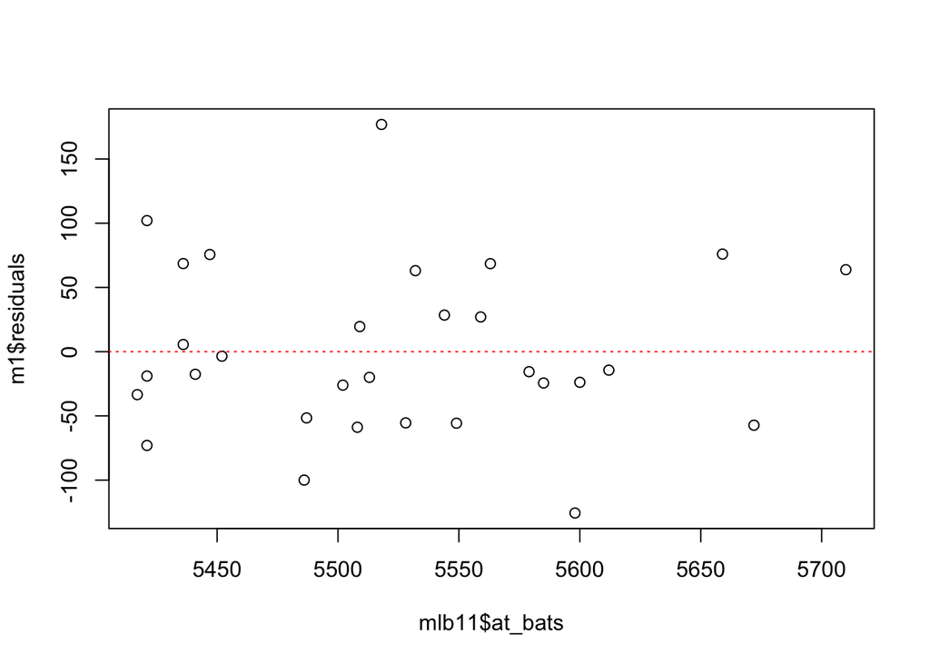

```r
plot(m1$residuals ~ mlb11$at_bats)
abline(h = 0, lty = 3, col = "red") # adds a horizontal line at y = 0  and the line type = 3 for dashed line
```

#Exercise 6

#Is there any apparent pattern in the residuals plot? #What does this indicate about the linearity of the relationship between runs and at-bats?

#Nearly normal residuals: To check this condition, we can look at a histogram

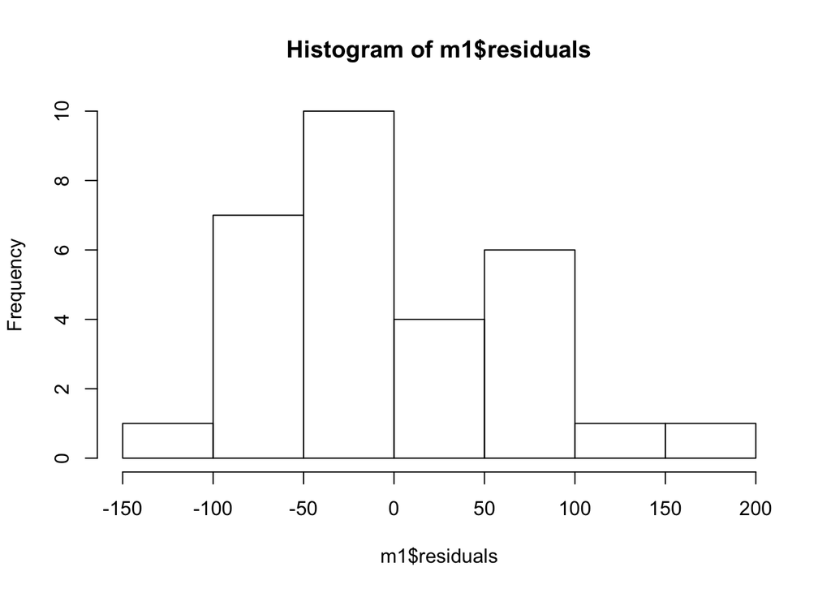

```r
hist(m1$residuals)
```

# or a normal probability plot of the residuals.

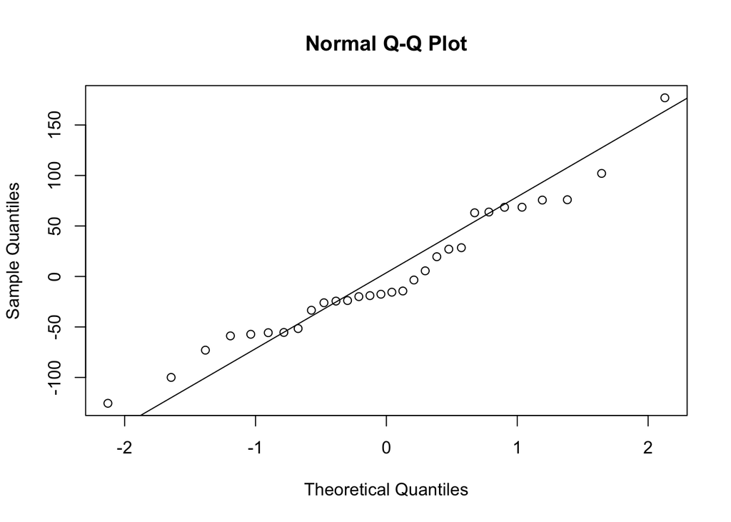

```r
qqnorm(m1$residuals)
#qqline(m1$residuals)
qqline(m1$residuals, names = FALSE, type = 'qtype', na.rm = TRUE) # adds diagonal line to the normal prob plot
```

# Exercise 7

# Based on the histogram and the normal probability plot,

# does the nearly normal residuals condition appear to be met?

Yes, the nearly normal residuals condition appear to be met

# Constant variability:

# Exercise 8

# Based on the plot in (1), does the constant variability condition appear to be met?

Yes, the constant variability condition appear to be met.

#On Your Own

#1.Choose another traditional variable from mlb11 that you think might be a good predictor of runs. Produce a scatterplot of the two variables and fit a linear model. At a glance, does there seem to be a linear relationship?

I am considering the batting average for the current exercize

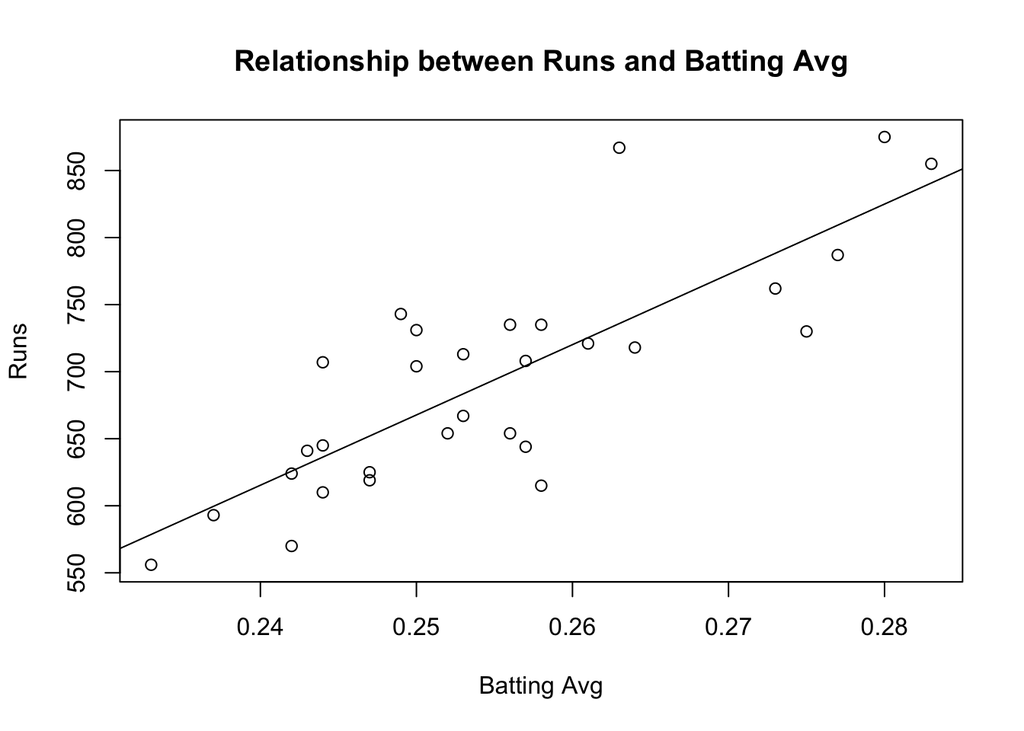

```r
lm1 <- lm(runs ~ bat_avg, data = mlb11)   #linear modal line
plot(mlb11$runs ~ mlb11$bat_avg, main = "Relationship between Runs and Batting Avg", xlab = "Batting Avg", ylab = "Runs")
abline(lm1)
```

```r
cor(mlb11$runs, mlb11$bat_avg)
```

```
## [1] 0.8099859
```

```r
summary(lm1)
```

```
##
## Call:
## lm(formula = runs ~ bat_avg, data = mlb11)
##
## Residuals:
##     Min      1Q  Median      3Q     Max
## -94.676 -26.303  -5.496  28.482 131.113
##
## Coefficients:
##             Estimate Std. Error t value Pr(>|t|)
## (Intercept)   -642.8      183.1  -3.511  0.00153 **
## bat_avg       5242.2      717.3   7.308 5.88e-08 ***
## ---
## Signif. codes:  0 '***' 0.001 '**' 0.01 '*' 0.05 '.' 0.1 ' ' 1
##
## Residual standard error: 49.23 on 28 degrees of freedom
## Multiple R-squared:  0.6561, Adjusted R-squared:  0.6438
## F-statistic: 53.41 on 1 and 28 DF,  p-value: 5.877e-08
```

#2.How does this relationship compare to the relationship between runs and at_bats? Use the R2

```r
runs = -642.8+5242.2*mlb11$bat_avg
runs
```

```
##  [1] 840.7426 825.0160 809.2894 798.8050 788.3206 741.1408 735.8986 725.4142
##  [9] 709.6876 709.6876 704.4454 704.4454 699.2032 699.2032 683.4766 683.4766
## [17] 678.2344 667.7500 667.7500 662.5078 652.0234 652.0234 636.2968 636.2968
## [25] 636.2968 631.0546 625.8124 625.8124 599.6014 578.6326
```

The linear model statistics and correlation coefficient for the relationship between runs and the batting average, it is evident that the relationship is positive, linear and relatively strong.

#values from the two model summaries to compare. Does your variable seem to predict runs better than at_bats? How can you tell?

#3.Now that you can summarize the linear relationship between two variables, investigate the relationships between runs and each of the other five traditional variables. Which variable best predicts runs? Support your conclusion using the graphical and numerical methods we’ve discussed (for the sake of conciseness, only include output for the best variable, not all five).

#at-bats, hits, home runs, batting average, strikeouts, stolen bases, and wins.

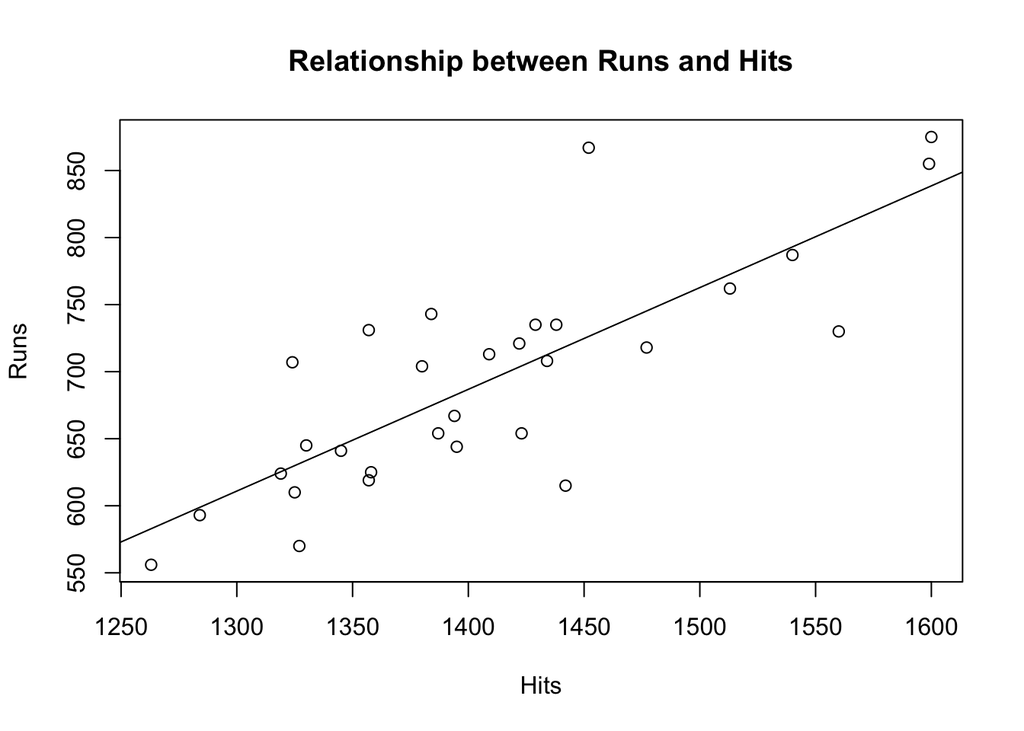

```r
lmhits <- lm(runs ~ hits, data = mlb11)   #linear modal line
plot(mlb11$runs ~ mlb11$hits, main = "Relationship between Runs and Hits", xlab = "Hits", ylab = "Runs")
abline(lmhits)
```

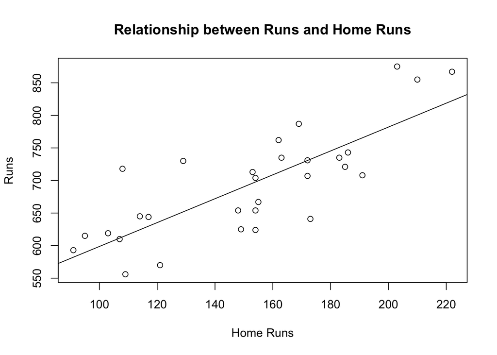

```r
lmhr <- lm(runs ~ homeruns, data = mlb11)   #linear modal line
plot(mlb11$runs ~ mlb11$homeruns, main = "Relationship between Runs and Home Runs", xlab = "Home Runs", ylab = "Runs")
abline(lmhr)
```

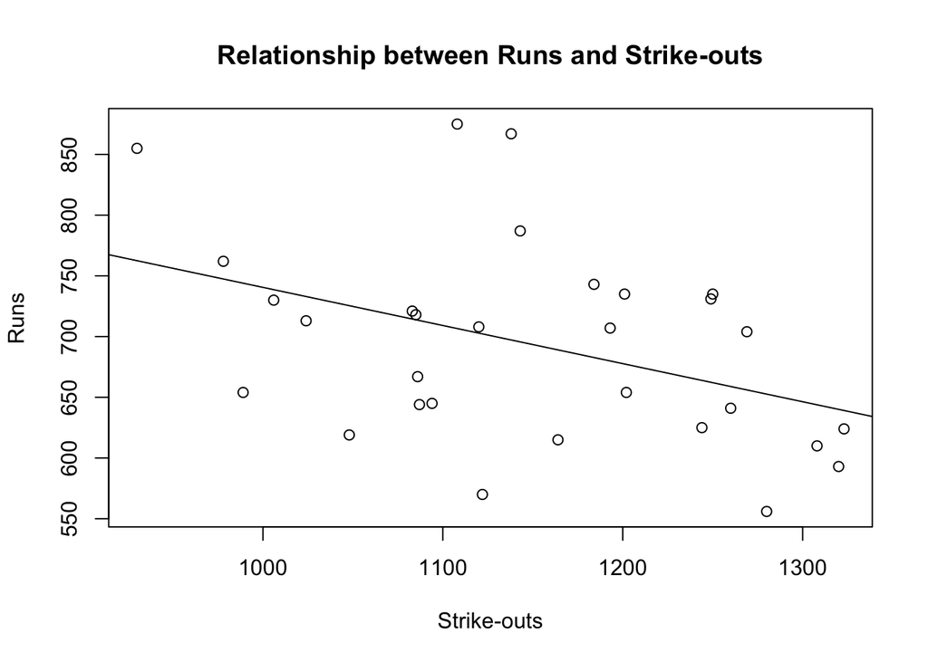

```r
lmso <- lm(runs ~ strikeouts, data = mlb11)   #linear modal line
plot(mlb11$runs ~ mlb11$strikeouts, main = "Relationship between Runs and Strike-outs", xlab = "Strike-outs", ylab = "Runs")
abline(lmso)
```

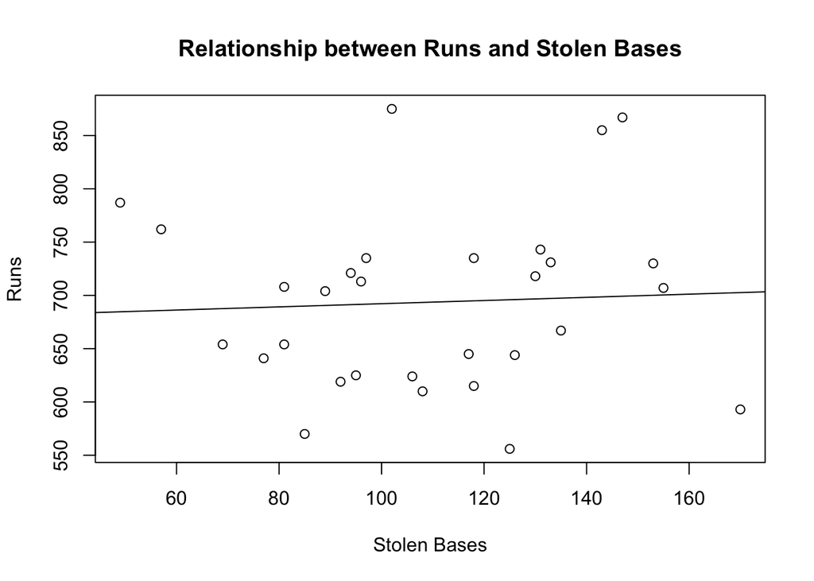

```r
lmsb <- lm(runs ~ stolen_bases, data = mlb11)   #linear modal line
plot(mlb11$runs ~ mlb11$stolen_bases, main = "Relationship between Runs and Stolen Bases", xlab = "Stolen Bases", ylab = "Runs")
abline(lmsb)
```

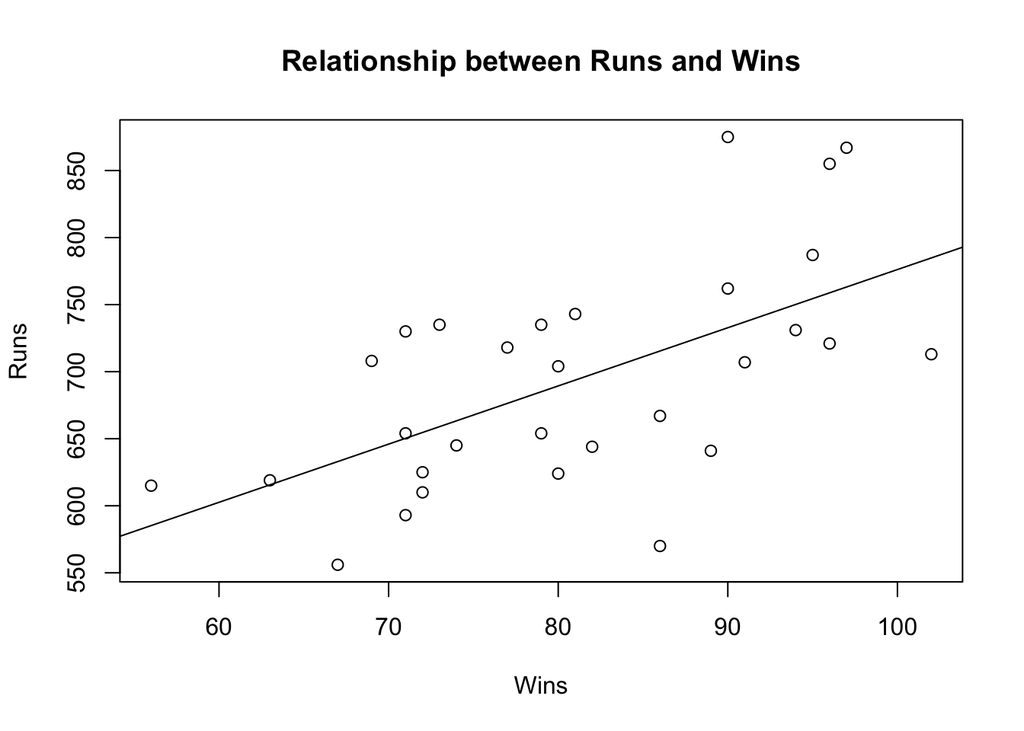

```r
lmwin <- lm(runs ~ wins, data = mlb11)   #linear modal line
plot(mlb11$runs ~ mlb11$wins, main = "Relationship between Runs and Wins", xlab = "Wins", ylab = "Runs")
abline(lmwin)
```

#4.Now examine the three newer variables. These are the statistics used by the author of Moneyball to predict a teams success. In general, are they more or less effective at predicting runs that the old variables? Explain using appropriate graphical and numerical evidence. Of all ten variables we’ve analyzed, which seems to be the best predictor of runs? Using the limited (or not so limited) information you know about these baseball statistics, does your result make sense?

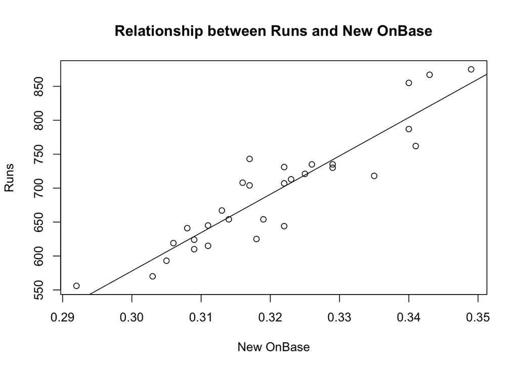

```r
lmNOB <- lm(runs ~ new_onbase, data = mlb11)   #linear modal line
plot(mlb11$runs ~ mlb11$new_onbase, main = "Relationship between Runs and New OnBase", xlab = "New OnBase", ylab = "Runs")
abline(lmNOB)
```

```r
cor(mlb11$new_onbase, mlb11$runs)
```

```
## [1] 0.9214691
```

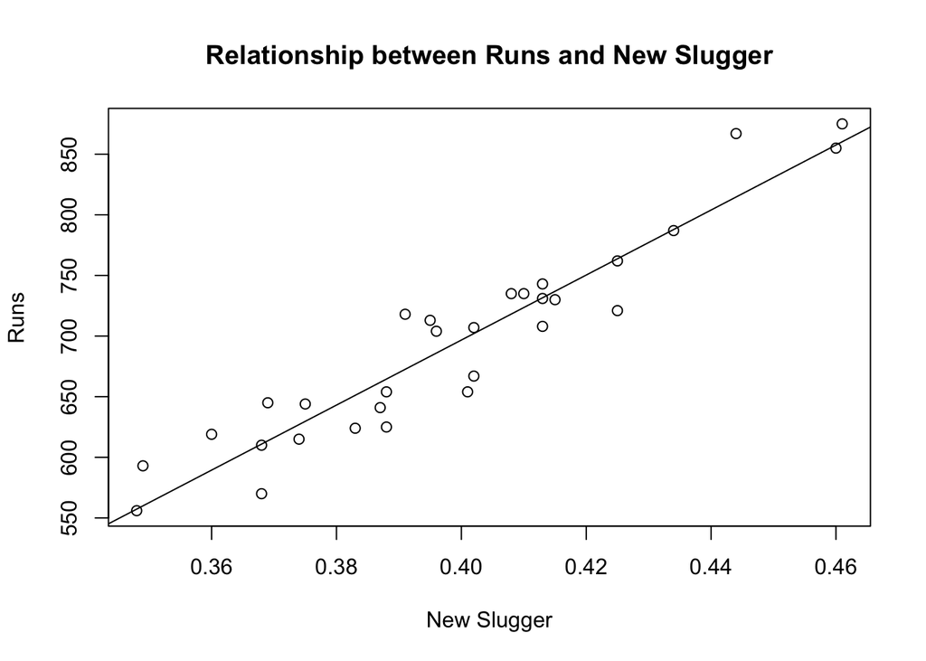

```r
lmnslug <- lm(runs ~ new_slug, data = mlb11)   #linear modal line
plot(mlb11$runs ~ mlb11$new_slug, main = "Relationship between Runs and New Slugger", xlab = "New Slugger", ylab = "Runs")
abline(lmnslug)
```

```r
cor(mlb11$new_slug, mlb11$runs)
```

```
## [1] 0.9470324
```

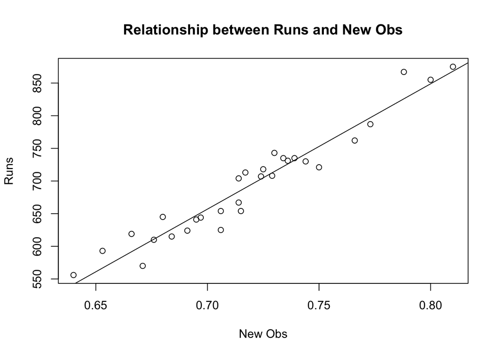

```r
lmnobs <- lm(runs ~ new_obs, data = mlb11)   #linear modal line
plot(mlb11$runs ~ mlb11$new_obs, main = "Relationship between Runs and New Obs", xlab = "New Obs", ylab = "Runs")
abline(lmnobs)
```

```r
cor(mlb11$new_obs, mlb11$runs)
```

```
## [1] 0.9669163
```

```r
summary(lmnobs)
```

```
##
## Call:
## lm(formula = runs ~ new_obs, data = mlb11)
##
## Residuals:
##     Min      1Q  Median      3Q     Max
## -43.456 -13.690   1.165  13.935  41.156
##
## Coefficients:
##             Estimate Std. Error t value Pr(>|t|)
## (Intercept)  -686.61      68.93  -9.962 1.05e-10 ***
## new_obs      1919.36      95.70  20.057  < 2e-16 ***
## ---
## Signif. codes:  0 '***' 0.001 '**' 0.01 '*' 0.05 '.' 0.1 ' ' 1
##
## Residual standard error: 21.41 on 28 degrees of freedom
## Multiple R-squared:  0.9349, Adjusted R-squared:  0.9326
## F-statistic: 402.3 on 1 and 28 DF,  p-value: < 2.2e-16
```

```r
summary(lmnslug)
```

```
##
## Call:
## lm(formula = runs ~ new_slug, data = mlb11)
##
## Residuals:
##    Min     1Q Median     3Q    Max
## -45.41 -18.66  -0.91  16.29  52.29
##
## Coefficients:
##             Estimate Std. Error t value Pr(>|t|)
## (Intercept)  -375.80      68.71   -5.47 7.70e-06 ***
## new_slug     2681.33     171.83   15.61 2.42e-15 ***
## ---
## Signif. codes:  0 '***' 0.001 '**' 0.01 '*' 0.05 '.' 0.1 ' ' 1
##
## Residual standard error: 26.96 on 28 degrees of freedom
## Multiple R-squared:  0.8969, Adjusted R-squared:  0.8932
## F-statistic: 243.5 on 1 and 28 DF,  p-value: 2.42e-15
```

```r
summary(lmNOB)
```

```
##
## Call:
## lm(formula = runs ~ new_onbase, data = mlb11)
##
## Residuals:
##     Min      1Q  Median      3Q     Max
## -58.270 -18.335   3.249  19.520  69.002
##
## Coefficients:
##             Estimate Std. Error t value Pr(>|t|)
## (Intercept)  -1118.4      144.5  -7.741 1.97e-08 ***
## new_onbase    5654.3      450.5  12.552 5.12e-13 ***
## ---
## Signif. codes:  0 '***' 0.001 '**' 0.01 '*' 0.05 '.' 0.1 ' ' 1
##
## Residual standard error: 32.61 on 28 degrees of freedom
## Multiple R-squared:  0.8491, Adjusted R-squared:  0.8437
## F-statistic: 157.6 on 1 and 28 DF,  p-value: 5.116e-13
```

From above graphs and the values, new_obs variable has the highest R-squared value and coefficient correlation values and appears to be the best and most effective predictor of the runs.

#5.Check the model diagnostics for the regression model with the variable you decided was the best predictor for runs.

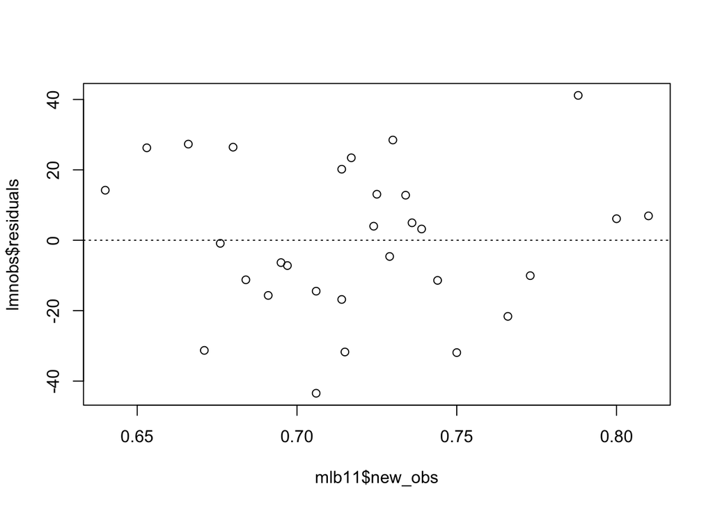

```r
plot(lmnobs$residuals ~ mlb11$new_obs)
abline(h = 0, lty = 3)
```

The Linearity of residuals is approximately constant across the distribution, but does not indicate any curvatures or any indication of non-normality

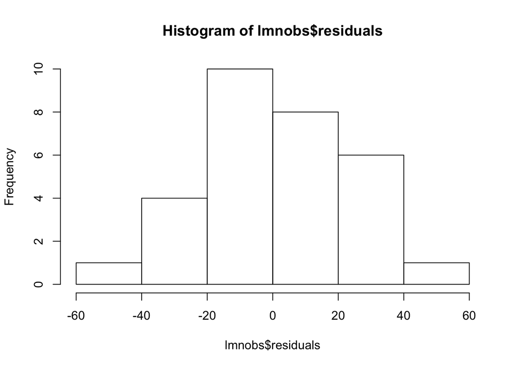

```r
hist(lmnobs$residuals)
```

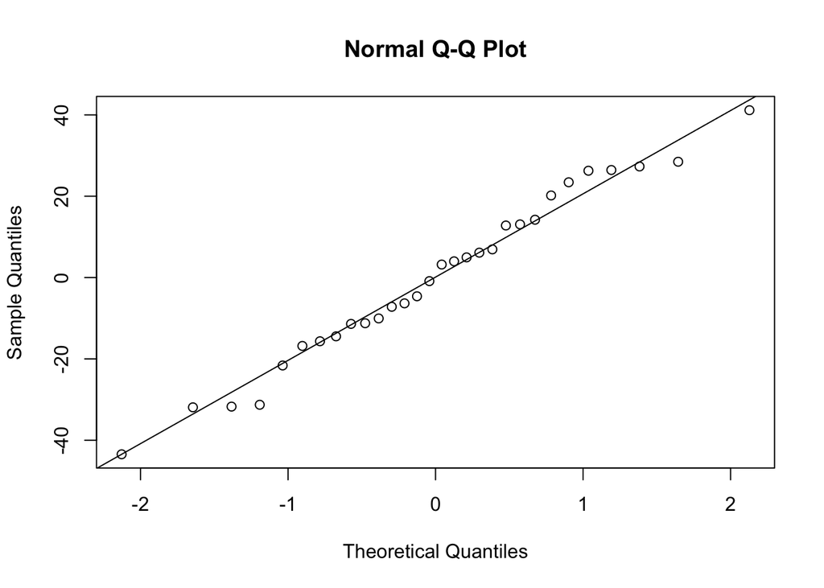

```r
qqnorm(lmnobs$residuals)
qqline(lmnobs$residuals)
```

from the above graph we can notify that residuals are approximately normaly ditributed and the modal meets the nearly normal residual condition.

3. Constatn Variablity: Based on the plot the variability of points around the least squares line are roughly constant so the condition constant variability has been met.